# Proje Rapor : Elif Zehra Yılmaz 200401077

# Q1 : Problem tanımı

Biz, Stratejinet Pazarlama Çözümleri, müşterilerimize özel pazarlama stratejileri sunan bir pazarlama danışmanlığı şirketiyiz. Müşterimiz, uyku hapı üretimi yapan bir firma. Problemimiz, uyku hapı için hedef kitle belirleme, kampanya oluşturma ve ürün stratejileri geliştirmedir.

# Q2 : Proje Amacı

Bu proje, [sleep health and lifestyle dataset](https://www.kaggle.com/datasets/uom190346a/sleep-health-and-lifestyle-dataset) adlı Kaggle veri setini kullanarak uyku hapı üretimi yapan bir firma için özel pazarlama stratejileri geliştirmeyi amaçlamaktadır. İlk olarak, hedef kitle belirleme ve demografik analiz yapılacak, potansiyel müşteri grupları ve onların ihtiyaçları daha detaylı bir şekilde incelenecektir.Analiz etapları, müşteri segmentasyonu ve pazarın genel yapısını anlamak için kullanılacak veri odaklı yöntemleri içerecektir.

Bu analizlerin sonucunda elde edilecek veriler, hedef kitleye özgü pazarlama kampanyalarının oluşturulmasına ve uyku hapının daha etkili bir şekilde pazarlanmasına olanak tanıyacaktır.

# Q3 : Veri seti keşifsel analizi

Veri seti Kaggle web sitesinden indirilmiştir ve **readr::read_csv()** fonksiyonu kullanılarak **spec_tbl_df** tipinde bir değişkene ithal edilmiştir. Veri boyutları aşağıdaki gibidir :

- Satır sayısı : 374
- Sütun sayısı : 13

Veri setinin ön görsellemesi aşağıda verilmiştir.

| Person ID | Gender | Age | Occupation | Sleep Duration | Quality of Sleep | Physical Activity Level | Stress Level | BMI Category | Blood Pressure | Heart Rate | Daily Steps | Sleep Disorder |
| --- | --- | --- | --- | --- | --- | --- | --- | --- | --- | --- | --- | --- |
| 1 | Male | 27 | Software Engineer | 6.1 | 6 | 42 | 6 | Overweight | 126/83 | 77 | 4200 | None |
| 2 | Male | 28 | Doctor | 6.2 | 6 | 60 | 8 | Normal | 125/80 | 75 | 10000 | None |
| 3 | Male | 28 | Doctor | 6.2 | 6 | 60 | 8 | Normal | 125/80 | 75 | 10000 | None |
| 4 | Male | 28 | Sales Representative | 5.9 | 4 | 30 | 8 | Obese | 140/90 | 85 | 3000 | Sleep Apnea |
| 5 | Male | 28 | Sales Representative | 5.9 | 4 | 30 | 8 | Obese | 140/90 | 85 | 3000 | Sleep Apnea |
| 6 | Male | 28 | Software Engineer | 5.9 | 4 | 30 | 8 | Obese | 140/90 | 85 | 3000 | Insomnia |
| 7 | Male | 29 | Teacher | 6.3 | 6 | 40 | 7 | Obese | 140/90 | 82 | 3500 | Insomnia |
| 8 | Male | 29 | Doctor | 7.8 | 7 | 75 | 6 | Normal | 120/80 | 70 | 8000 | None |
| 9 | Male | 29 | Doctor | 7.8 | 7 | 75 | 6 | Normal | 120/80 | 70 | 8000 | None |
| 10 | Male | 29 | Doctor | 7.8 | 7 | 75 | 6 | Normal | 120/80 | 70 | 8000 | None |

[output cut: 364 more lines]

Veri setini incelediğimizde, problem çözümü için kullanacağımız sütunlardan Occupation sütununun bazı kayıtlarında Engineer, bazı kayıtlarında Software Engineer yazdığını görüyoruz. Bu durum tutarlılık sorunlarına neden olabilir. Software Engineer yazan kayıtlar, Engineer olarak düzeltilmelidir.

Aynı şekilde, BMI Category sütununda bazı kayıtlarda Normal, bazılarında Normal Weight yazdığını görüyoruz. Tutarlılık sorununa neden olmaması için Normal yazan kayıtlar, Normal Weight olarak düzeltilmelidir.

Yaş verilerinin dağılımı aşağıdaki histogramda gösterilmiştir.

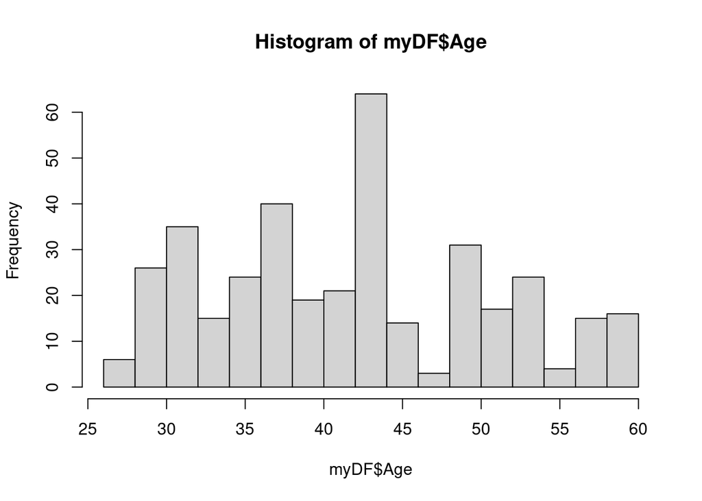

Uyku bozukluğu verilerinin dağılımı aşağıdaki grafikte verilmiştir.

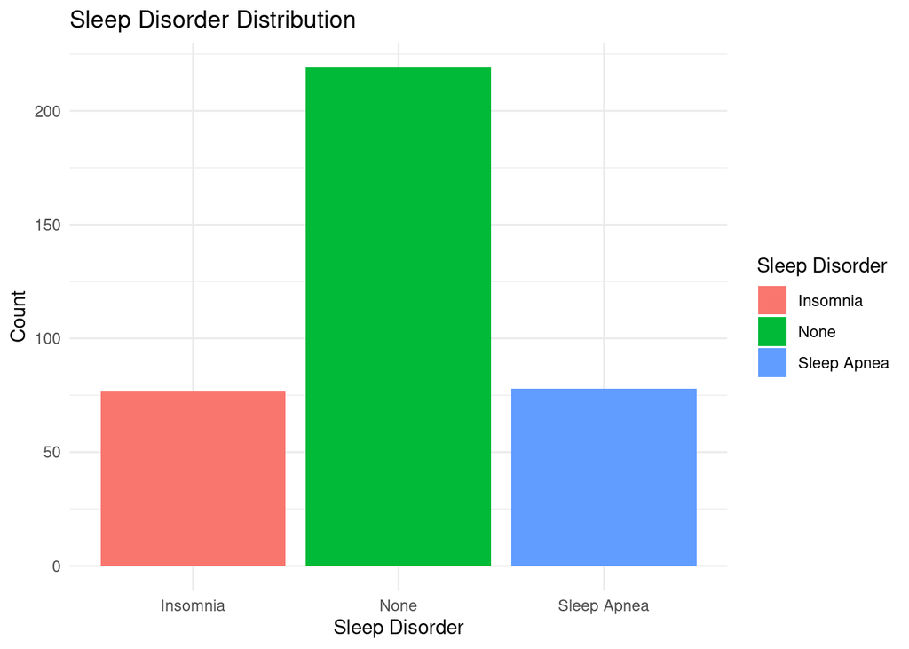

Çoğu veride herhangi bir uyku bozukluğu görülmezken Insomnia ve Sleep Apnea aynı oranda görülmektedir. Kampanya oluştururken bu iki uyku bozukluğuna da aynı derecede önem verilmesi gerekmektedir.

# Q4 : Veri seti ön işlemesi

## Occupation Sütunu

```
## # A tibble: 67 × 1
##    Occupation
##    <chr>
##  1 Engineer
##  2 Engineer
##  3 Engineer
##  4 Engineer
##  5 Engineer
##  6 Engineer
##  7 Engineer
##  8 Engineer
##  9 Engineer
## 10 Engineer
## # ℹ 57 more rows
```

Occupation sütunundaki Software Engineer kayıtları Engineer kayıtlarına dönüştürülmüştür.

## BMI Category Sütunu

```
## # A tibble: 216 × 1
##    `BMI Category`
##    <chr>
##  1 Normal Weight
##  2 Normal Weight
##  3 Normal Weight
##  4 Normal Weight
##  5 Normal Weight
##  6 Normal Weight
##  7 Normal Weight
##  8 Normal Weight
##  9 Normal Weight
## 10 Normal Weight
## # ℹ 206 more rows
```

BMI Category sütunundaki Normal kayıtları, Normal Weight kayıtlarına dönüştürülmüştür.

# Q5 : Veri mühendisliği

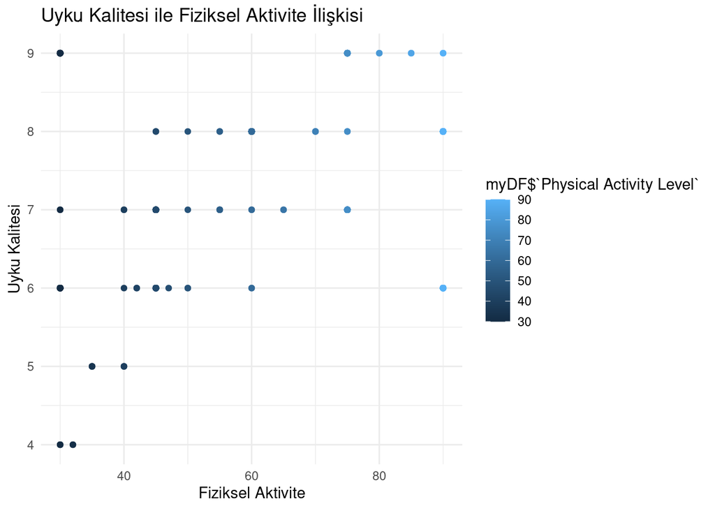

Grafikten görüldüğü üzere fiziksel aktivite arttıkça uyku kalitesi de artmaktadır. Fiziksel aktivitesi düşük olan kişilere uyku sorunlarına çözüm sunan bir ürüne odaklanılması ve bu kişilere yönelik kampanyalar yapılması gerekmektedir.

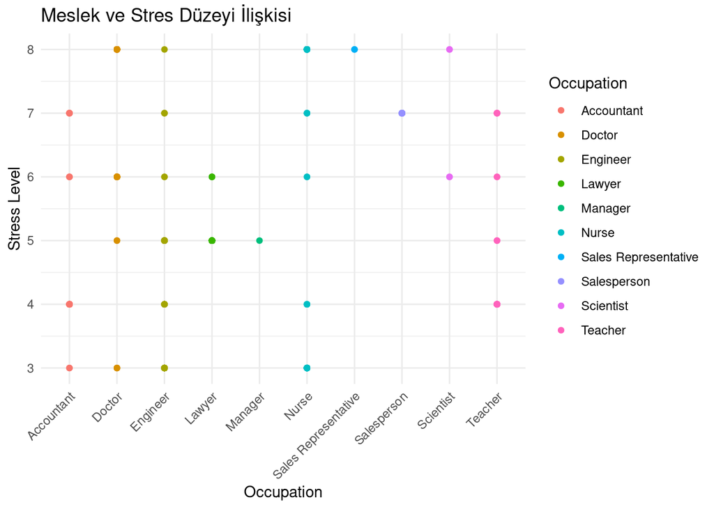

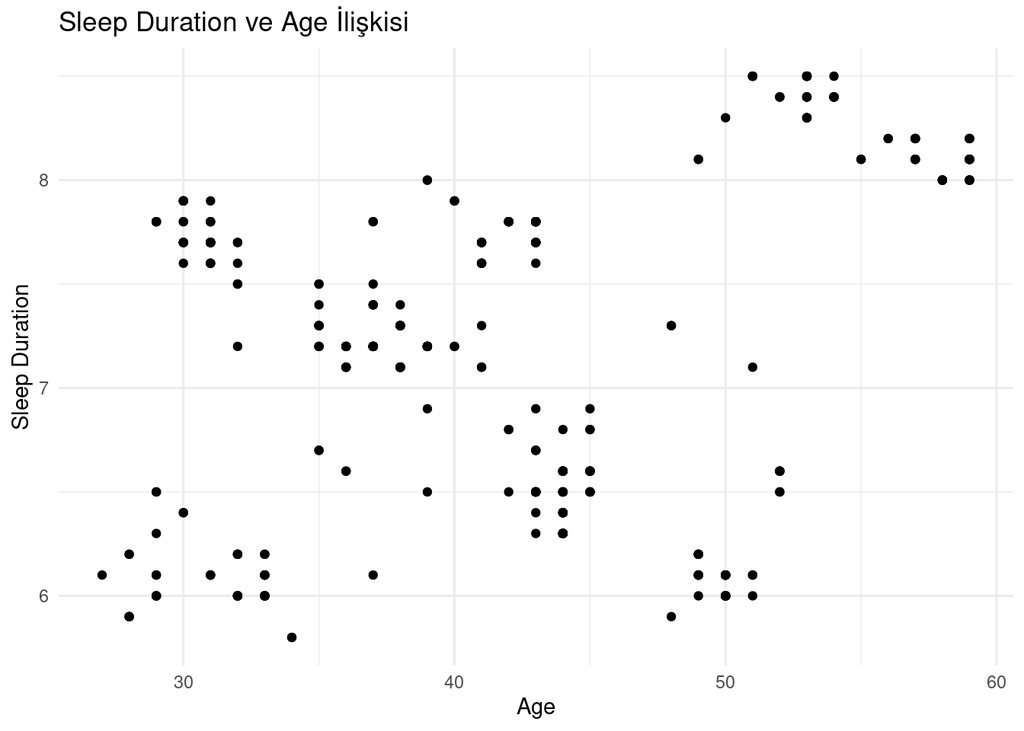

Bu grafikte, orta yaş gruplarının ileri yaş gruplarına göre daha az uyuduğu görülmektedir. Orta yaş grupları kampanyalarda dikkate alınmalıdır.

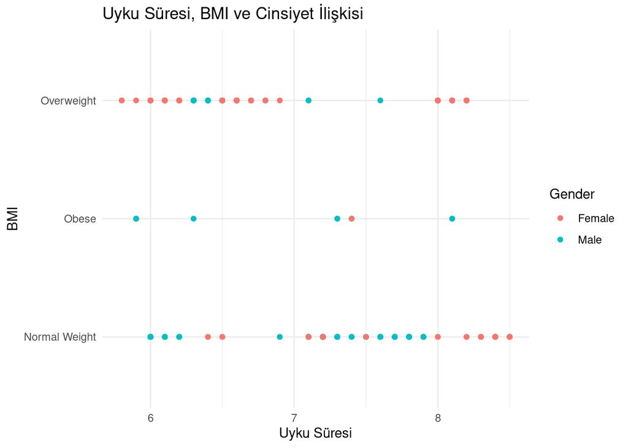

Bu grafikte, overweight kadınların daha fazla olduğu ve uyku sürelerinin daha kısa olduğu görülmektedir. Bu da kampanyada dikkate alınmalıdır.

# Q7 : Sonuç değerlendirme, tavsiyeler

1. **Sonuçların Mantıklılığı:**
   - Yaptığımız çıkarımlar mantıklı görünmektedir. Ancak, daha fazla analiz, derinleme ve belki de alan uzmanları veya sağlık profesyonelleri ile işbirliği yaparak elde ettiğimiz sonuçlar daha güvenilir olabilir.
2. **Ana Problemi Çözme Yetisi:**
   - Elde edilen sonuçların, proje başlangıcındaki ana problemi çözmede başarılı olduğu söylenebilir.
3. **Müşteri Kullanımı:**
   - Elde edilen sonuçlar müşteriler tarafından hedef kitleleri belirleyerek kampanya kurmasında, uyku hapının niteiklerini belirlemede katkı sağlar.
4. **Analizin Kuvvetli ve Zayıf Yanları:**
   - Analizin güçlü yanları, kullanılan etkili analiz yöntemleri ve doğru veri seti seçimi. Zayıf yanlar arasında, belki de daha fazla veri toplama veya belirli bir analiz yöntemini daha derinlemesine inceleme olabilir.
5. **Çalışmanın İyileştirilmesi ve İlerletilmesi:**
   - Bu çalışmayı ileride iyileştirmek için daha fazla veri toplama ve belirli analiz tekniklerini daha derinlemesine inceleme gerekebilir.
6. **Tavsiyeler:**
   - Daha kapsamlı veriseti kullanma, neden-sonuç ilişkilerini daha derinlemesine araştırmak ve analiz etme, analize dahil edilmemiş ancak önemli olabilecek diğer değişkenleri göz önünde bulundurma. Bu tavsiyeler, çalışmanın daha etkili ve kapsamlı hale gelmesine katkı sağlayabilir.